# Exponential Distribution

## Mendekati normal distribution

Berikut merupakan bentukha distribusi dari simulasi yang dilakukan, bentuknya mendekati dengan normal distribution (Gaussian)

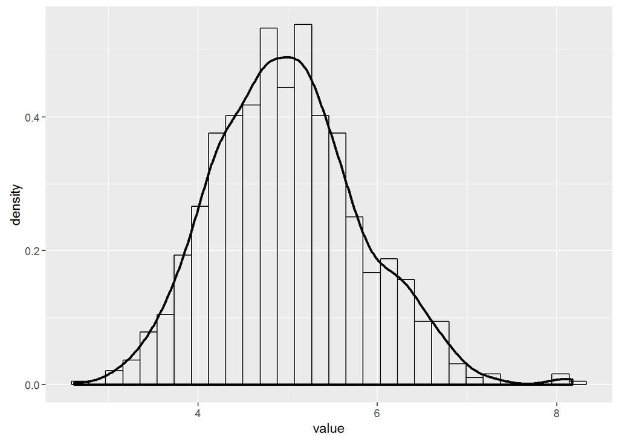

```r
plots <- ggplot(data=melt(sim_mean), aes(value,..density..))
plots +  geom_density(kernel = "gaussian", col = 'black',size = 1) + geom_histogram(colour="black", fill = "NA") #density disini sebagai sumbu y,yang merepresentasikan banyaknya count/total count
```

Q-Q plot digunakan untuk menentukan apakah dua data set diambil dari populasi dengan distribusi yang sama. Diplot dengan membandingkan nilai quantile data 1 dengan data 2. Di R, dapat dicari dengan menggunakan qqplot. qqnorm digunakan untuk membandingkan quantile data dengan normal distribution (yang secara teori)

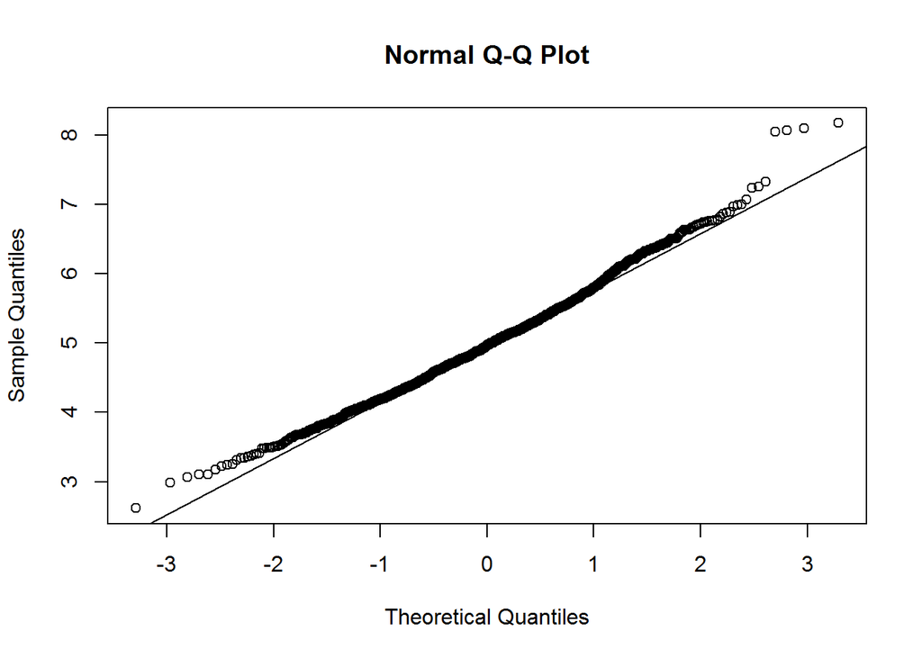

```r
qqnorm(sim_mean)
qqline(sim_mean)
```

```r
kurtosis(sim_mean)
```

```
## [1] 3.294639
```

```r
skewness(sim_mean)
```

```
## [1] 0.3720154
```

```r
summary(sim_mean)
```

```
##    Min. 1st Qu.  Median    Mean 3rd Qu.    Max.
##   2.618   4.412   4.970   5.000   5.505   8.172
```

kesimpulannya theorema CLT berlaku disini, dimana sample yang banyak akan mendekati distribusi normal